# TD2- Advanced Times Series

### Question 2 : Calculons la valeur du AIC pour différentes valeur de retard et trouvons la valeur p qui minimise le AIC.

Nous allons calculer nos critères jusqu’à 5 retards

```r
bic <- numeric(5)
aic <- numeric(5)
```

Voici nos nouvelles données différenciés une fois :

```r
canadadiff <- data.frame(diffemployment,difflabor, diffrealwages, diffunemployement)
for (lag in 1:5){
  var <- VAR(canadadiff, p=lag, type="const")
  bic[lag] <- BIC(var)
  aic[lag] <- AIC(var)
}
print(aic)
```

```
## [1] 467.5692 444.1755 452.2890 439.9115 445.1268
```

```r
print(bic)
```

```
## [1] 515.7036 530.3756 576.1544 601.0340 643.0904
```

Je sélectionne maintenant le niveau de aic et bic le plus petit pour définir le nombre de retards à prendre.

```r
lagBIC <- which.min(bic)
lagAIC <- which.min(aic)
lagBIC
```

```
## [1] 1
```

```r
lagAIC
```

```
## [1] 4
```

```r
plag = lagBIC
```

BIC m’indique de prendre 1 retard tandis que AIC me conseille de prendre 4 retard. BIC est mieux en général dans le cas des VAR et est souvent plus faible ici donc facilite les calculs.

### Question 3 : Estimons les valeurs des coefficients de notre modèle VAR avec le bon nombre de retard

```r
modelVAR = VAR(canadadiff, p = plag, type = "const")
modelVAR
```

```
##
## VAR Estimation Results:
## =======================
##
## Estimated coefficients for equation diffemployment:
## ===================================================
## Call:
## diffemployment = diffemployment.l1 + difflabor.l1 + diffrealwages.l1 + diffunemployement.l1 + const
##
##    diffemployment.l1         difflabor.l1     diffrealwages.l1
##           0.74083297           0.18427931          -0.05207171
## diffunemployement.l1                const
##           0.14031384           0.13181630
##
##
## Estimated coefficients for equation difflabor:
## ==============================================
## Call:
## difflabor = diffemployment.l1 + difflabor.l1 + diffrealwages.l1 + diffunemployement.l1 + const
##
##    diffemployment.l1         difflabor.l1     diffrealwages.l1
##          -0.42334602           0.24426975          -0.02005895
## diffunemployement.l1                const
##          -0.85238362           0.29282997
##
##
## Estimated coefficients for equation diffrealwages:
## ==================================================
## Call:
## diffrealwages = diffemployment.l1 + difflabor.l1 + diffrealwages.l1 + diffunemployement.l1 + const
##
##    diffemployment.l1         difflabor.l1     diffrealwages.l1
##            0.1439871           -0.3064895            0.3337161
## diffunemployement.l1                const
##            0.4593971            0.6481169
##
##
## Estimated coefficients for equation diffunemployement:
## ======================================================
## Call:
## diffunemployement = diffemployment.l1 + difflabor.l1 + diffrealwages.l1 + diffunemployement.l1 + const
##
##    diffemployment.l1         difflabor.l1     diffrealwages.l1
##          -0.50251316          -0.13648147           0.06514647
## diffunemployement.l1                const
##          -0.12720924           0.13588226
```

### Question 4 : Calculons les résidus des variables et de la matrice variance-covariance.

```r
residus = residuals(modelVAR)
covarianceresid = cov(residus)
covarianceresid
```

```
##                   diffemployment     difflabor diffrealwages diffunemployement
## diffemployment       0.143059172  0.0068664254 -0.0442137816       -0.07981192
## difflabor            0.006866425  0.4312312831  0.0001892408       -0.01642931
## diffrealwages       -0.044213782  0.0001892408  0.8205586472        0.07227370
## diffunemployement   -0.079811921 -0.0164293089  0.0722736974        0.09334055
```

Matrice covariance variance pas diagonale donc enfaite nos résidus sont corrélés ce qui signifie que les erreurs sont potentiellements non significativité car lien entre nos résidus.

### Question 5 : Obtenons les coefficients de la matrice ψ de notre VMA(infini) representation

Déjà on peut affirmer qu’une représentation sous forme d’un VMA(infini) est possible car nous avons un VAR bien stationnaire.

```r
Psi(modelVAR)
```

```
## , , 1
##
##             [,1]         [,2]      [,3]      [,4]
## [1,]  0.38793146  0.000000000 0.0000000 0.0000000
## [2,]  0.01861959  0.673265341 0.0000000 0.0000000
## [3,] -0.11989386  0.003611422 0.9213021 0.0000000
## [4,] -0.21642482 -0.019684719 0.0544352 0.2190868
##
## , , 2
##
##             [,1]       [,2]        [,3]        [,4]
## [1,]  0.26669930  0.1211188 -0.04033576  0.03074091
## [2,]  0.02720088  0.1811648 -0.06488002 -0.18674601
## [3,] -0.08928503 -0.2141867  0.33246074  0.10064785
## [4,] -0.17776132 -0.0891489  0.05309492 -0.02786987
##
## , , 3
##
##             [,1]        [,2]        [,3]        [,4]
## [1,]  0.18229905  0.12175797 -0.05169996 -0.02079098
## [2,]  0.04705006  0.07326336 -0.05069829 -0.03689352
## [3,] -0.08139441 -0.15051788  0.14941638  0.08244646
## [4,] -0.12093605 -0.08820237  0.04402865  0.02014181
##
## , , 4
##
##             [,1]        [,2]        [,3]        [,4]
## [1,]  0.13099284  0.09916495 -0.04924622 -0.02366831
## [2,]  0.03903392  0.04455176 -0.03102353 -0.01903253
## [3,] -0.07089194 -0.09567303  0.07818366  0.04508065
## [4,] -0.08794751 -0.06976962  0.03703238  0.01829189
##
## , , 5
##
##             [,1]        [,2]        [,3]        [,4]
## [1,]  0.09558817  0.07686684 -0.04107522 -0.02082239
## [2,]  0.03046654  0.03029115 -0.01986400 -0.01112517
## [3,] -0.05716282 -0.06335577  0.04552128  0.02587272
## [4,] -0.06458366 -0.05326960  0.02936354  0.01510117
##
```

[output cut: 32 more lines]

```
## , , 10
##
##             [,1]         [,2]         [,3]         [,4]
## [1,]  0.02122583  0.018192508 -0.010458048 -0.005492850
## [2,]  0.00723622  0.006262226 -0.003637318 -0.001919054
## [3,] -0.01412106 -0.012287953  0.007178979  0.003797150
## [4,] -0.01445086 -0.012399939  0.007137016  0.003750595
##
## , , 11
##
##             [,1]         [,2]         [,3]         [,4]
## [1,]  0.01576594  0.013531580 -0.007790349 -0.004094390
## [2,]  0.00538265  0.004643935 -0.002688592 -0.001416503
## [3,] -0.01051269 -0.009097004  0.005283441  0.002787453
## [4,] -0.01073553 -0.009219782  0.005311524  0.002792405
```

### Question 6 : Calcuons l’ensemble des fonctions impulsions et vérifions la stabilité.

On va simuler un choc sur une variable et étudier les évolutions des autres variables sur des périodes postérieures à ce choc.

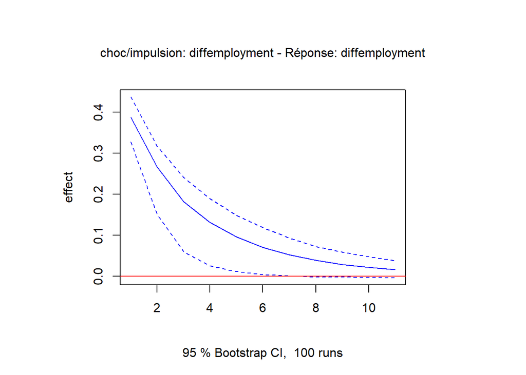

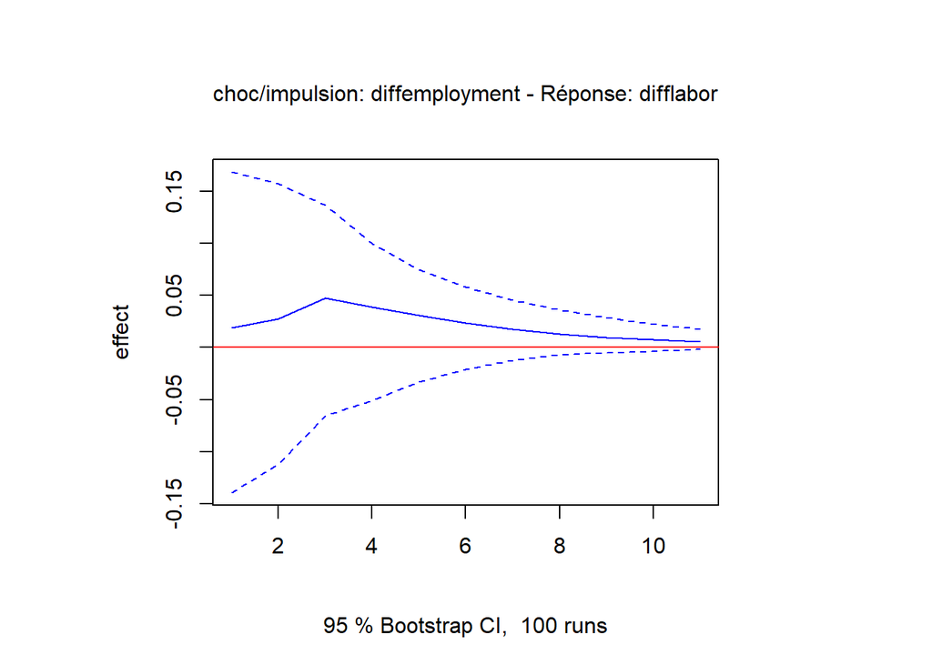

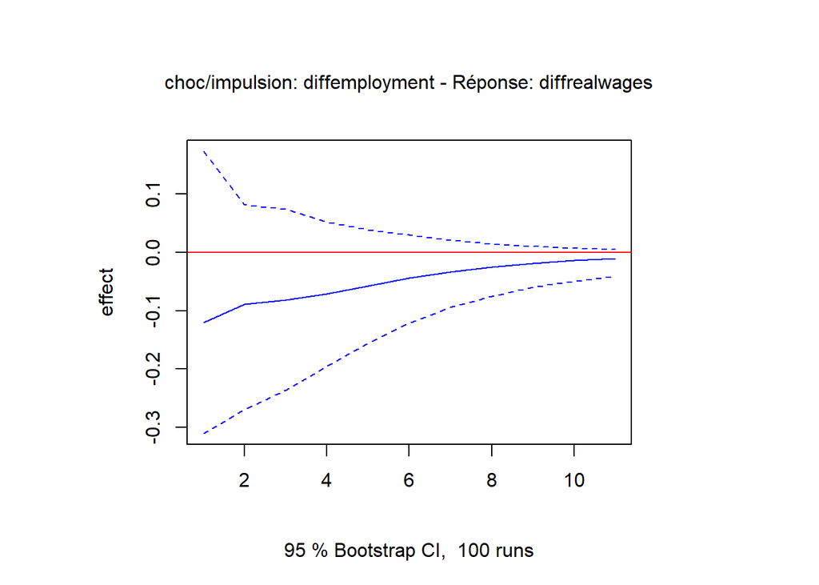

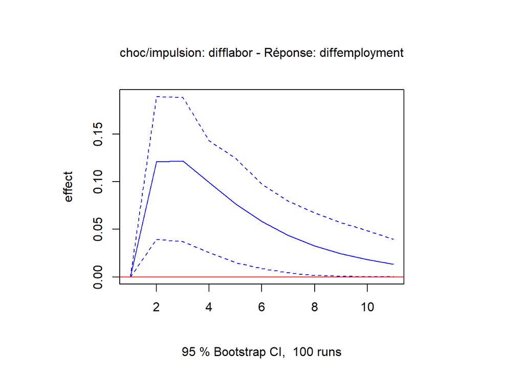

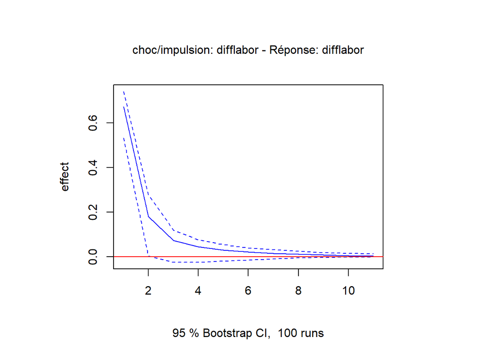

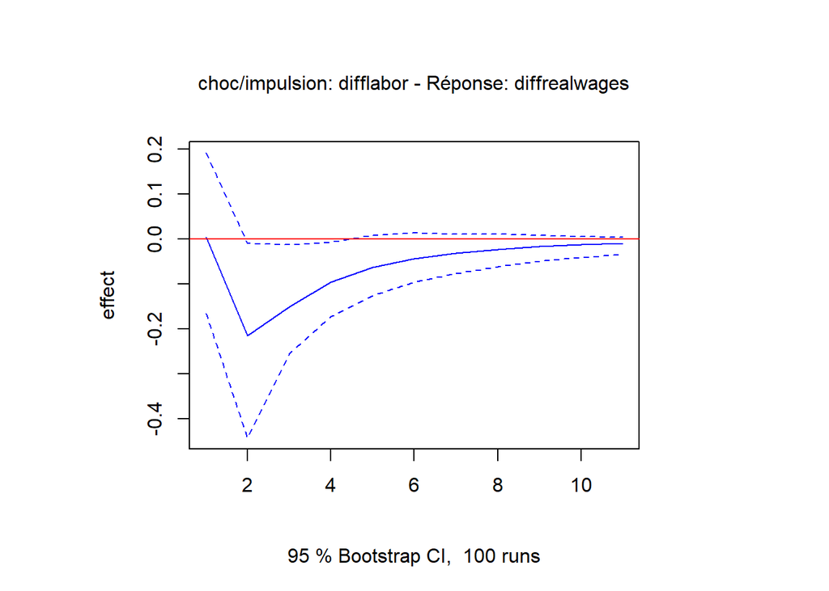

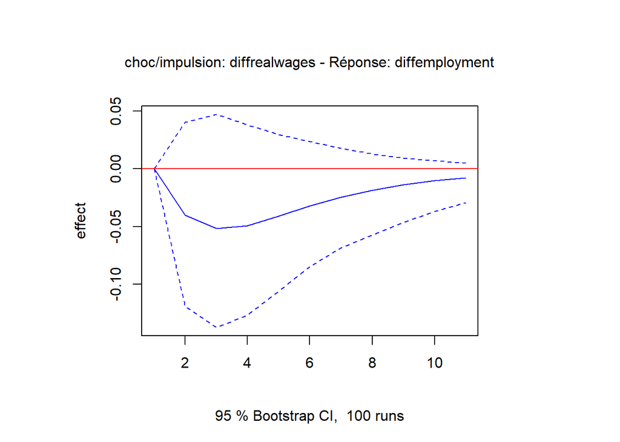

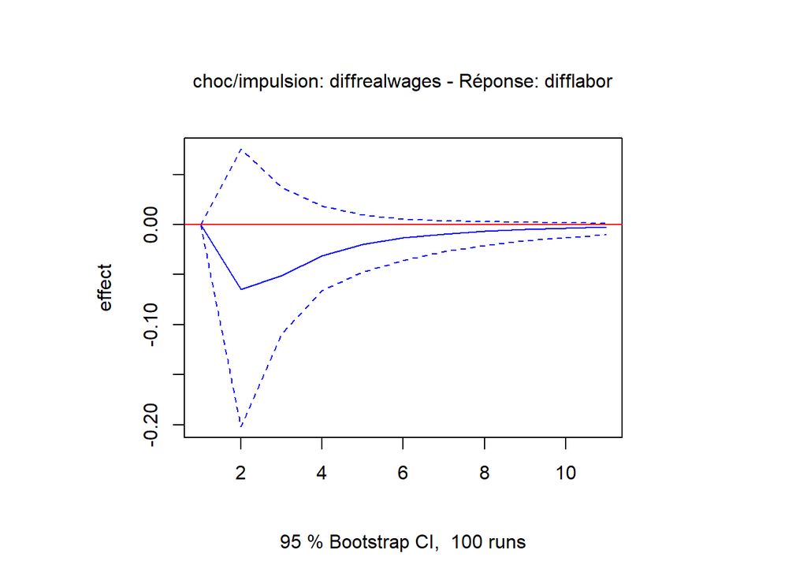

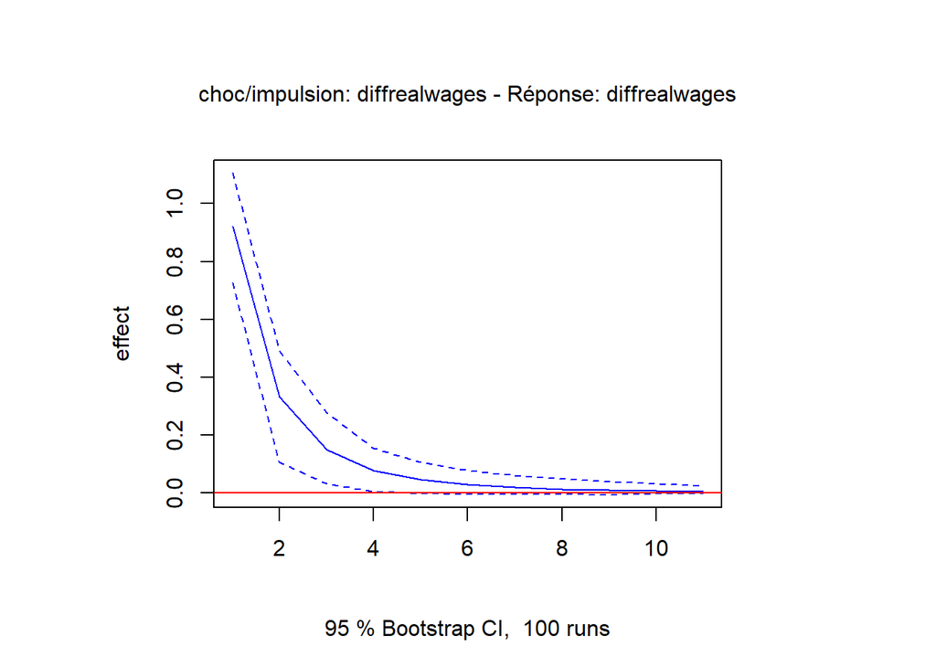

```r
noms_endogenes <- colnames(modelVAR$y)
nomsvariables <- c("diffemployment", "difflabor", "diffrealwages", "diffunemployment")
i <- 1
j <- 1
plotchoc <- list()

while (i <= length(nomsvariables)) {
  while (j <= length(nomsvariables)) {
    if (nomsvariables[i] %in% noms_endogenes & nomsvariables[j] %in% noms_endogenes) {
      ir <- irf(modelVAR, impulse = nomsvariables[i], response = nomsvariables[j], n.ahead = 10)
      irfunct <- plot(ir, main = paste("choc/impulsion:", nomsvariables[i], "- Réponse:", nomsvariables[j]),
                                col = c("blue", "red"), ylab = "effect", xlab = "Période")

      plotchoc[[length(plotchoc) + 1]] <- irfunct
    }
    j <- j + 1
  }
  i <- i + 1
  j <- 1
}
```

L’impulsion sur l’emploi entraîne un choc positif dans un premier temps sur productivité du travail, logique d’un point de vue économique. Mais ce n’est pas très significatif car 0 appartient à l’intervalle de confiance. L’impulsion sur l’emploi entrâine un choc négatif sur les salaires réels. Pas significatif L’impulsion sur la productivité au travail entraîne un choc positif sur les emplois.Logique d’un point de vue économique. L’impulsion sur la productivité au travail entraîne un choc négatif significatif sur les salaires réels. L’impulsion sur les salaires réels entraîne choc non significatif négatif sur les emplois. L’impulsion sur salaires réels entraîne choc non significatif négatif sur la productivité au travail.

On regarde les racines de notre modèles VAR et ont vérifie qu’elles sont inférieures à 1 en module.

```r
roots <- roots(modelVAR)
roots
```

```
## [1] 0.74310551 0.40100508 0.10945167 0.06195264
```

Elles sont bien inférieures à 1, ainsi notre VAR est bien stationnaire.

# Causalité au sens de Granger

### Question 1 : Générer le modèle VAR(3,2) écrit dans l’énoncé

```r
set.seed(123)
t<-1000
n <- 3 #variables
p <- 2 #lags
e <- mvrnorm(n= t, mu = rep(0, n), Sigma = diag(n))
c <- matrix(c(4,8,3),n) #
A.1 <- matrix(c(-.5,-.1,0,.2,0,.2,-0.4,-.6,.1),nrow =n, byrow = TRUE)
A.2 <- matrix(c(.3,.1,0,.1,-.3,-.1,0,-.2,.3),nrow =n, byrow = TRUE) #coeff matrix of lag 2
series <- matrix(0,nrow=t,ncol=n)#raw series with zeros


for (i in (p+1):(t)){
  series[i,]<- c+e[i,] + A.1%*%series[i-1,]+A.2%*%series[i-2,]
}
#series
```

### Question 2 :vérifions la stationnarité du modèle en affichant les racines du modèle

```r
model <- VAR(series, p = p)
roots <- roots(model)
roots
```

```
## [1] 0.7744052 0.6758003 0.6758003 0.5546588 0.5111163 0.4455758
```

```r
model1 <- data.frame(series)
```

Les racines du VAR sont inférieures à 1 en module, donc ce VAR(3,2) est bien stationnaire.

### Question 3 : Rappeler la définition de la causalité au sens de Granger

Selon le cours, au sens de granger, on dit que la variable x cause la variable y si et seulement si la connsiance du passé de xt améliore la précision de yt pour tout horizon.

### Question 4 : Faire un test de causalité au sens de granger et valider le fait que la troisième variable ne cause pas la première variable. Et prouver que la deuxième variable cause la troisième.

On peut utiliser la fonction grangertest :

```r
grangertest(X1 ~ X3, order = 2, data = model1)
```

```
## Granger causality test
##
## Model 1: X1 ~ Lags(X1, 1:2) + Lags(X3, 1:2)
## Model 2: X1 ~ Lags(X1, 1:2)
##   Res.Df Df      F Pr(>F)
## 1    993
## 2    995 -2 0.7865 0.4557
```

Ici on remarque que le modèle qui écrit X1 avec X3 et X1 est moins bien que simplement avec X1. p>0.05 donc on conclut que X3 ne cause pas X1.

```r
grangertest(X3 ~ X2, order = 2, data = model1)
```

```
## Granger causality test
##
## Model 1: X3 ~ Lags(X3, 1:2) + Lags(X2, 1:2)
## Model 2: X3 ~ Lags(X3, 1:2)
##   Res.Df Df      F    Pr(>F)
## 1    993
## 2    995 -2 242.38 < 2.2e-16 ***
## ---
## Signif. codes:  0 '***' 0.001 '**' 0.01 '*' 0.05 '.' 0.1 ' ' 1
```

Ici on remarque que le modèle qui écrit X3 avec X3 et X2 est bien meilleur que simplement avec X3. p<0.05 donc on conclut que X2 cause X3.

### Question 5 : Faire la réponse impulsionnelle du modèle et est ce que ca valide la structure du modèle ?

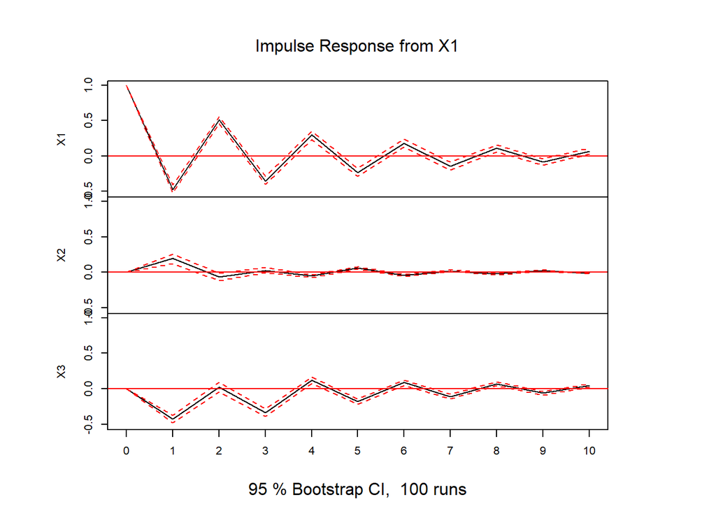

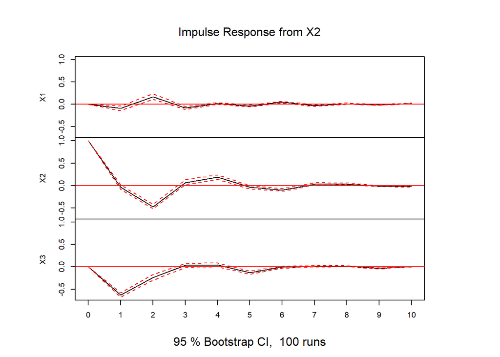

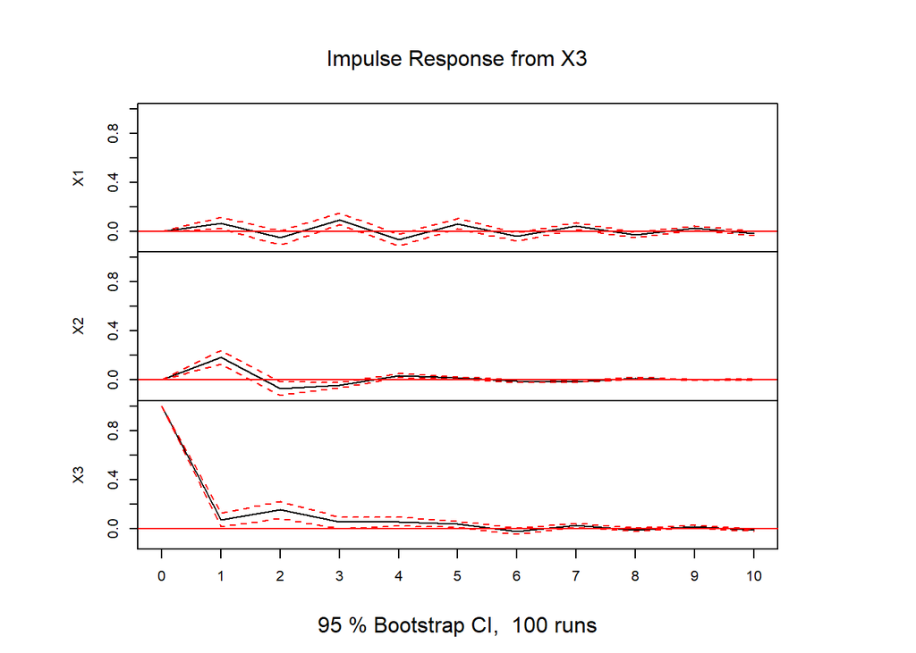

```r
newvar= VAR(model1,lag=2,type="const")
reponse <- irf(newvar, impulse = c("X1", "X2", "X3"), response = c("X1", "X2", "X3"), n.ahead = 10, ortho = FALSE)
plot(reponse)
```

On remarque qu’une fois un choc mis sur nos 3 variables, celle-ci retrouve leurs états initials après quelques temps. Cela indique une bonne stationnarité de nos séries étudiées.Donc notre stucture de VAR est bonne !

### Question 6 : Expliquer ce qu’est la FEDV et afficher la FEDV de notre VAR.

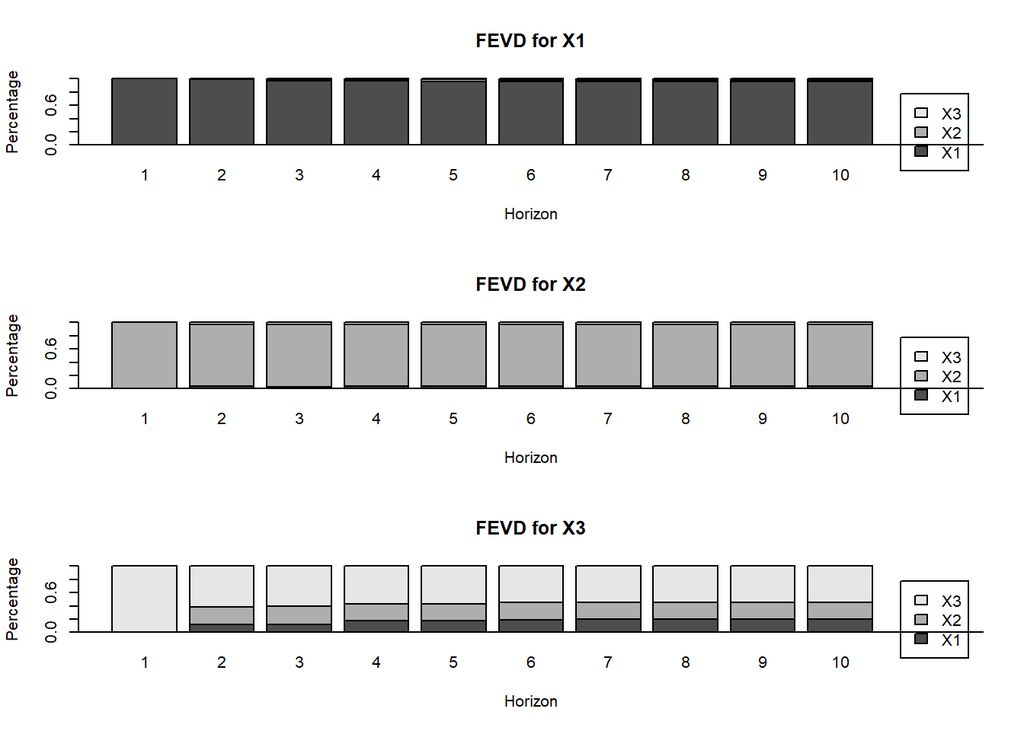

```r
fevd <- fevd(newvar, n.ahead = 10)
plot(fevd)
```

La FEVD signifie forevast eror variance decomposition et sert à analyser la contribution de chaque variable à la prévision des erreur de chaque autre variable du système. En gros, on peut comprendre les relations dans la prédiction de l’évolution des autres variables. Il existe une fonction sur R qui s’appelle fevd() qui nous permet justement de calculer ca. Ici on a la variable X1 qui a une contirbution de ses erreurs propres à elle comme pour X2. Cependant X3 a une contribution de X1 et X2 dans ses erreurs. Seule environ 50% de ses erreurs est expliquée par le contribution d’elle-même X3.

# VAR for Real - Homework

### Question 1 : Créer une base de donnée qui contient la data requis et plot les données. Proposez une interprétation économique et financière des probables liens entre ce jeu de variables.

1ère variable : pente de la courbe des rdt (#anticipation du marché sur la croissance américaine) 2ème variable : seuil d’inflation sur 10 ans {#inflation attendue} 3ème variable : Indice VIX (volatilité implicite du s&p500)

Importation de la courbe des taux :

```r
library(dplyr)
```

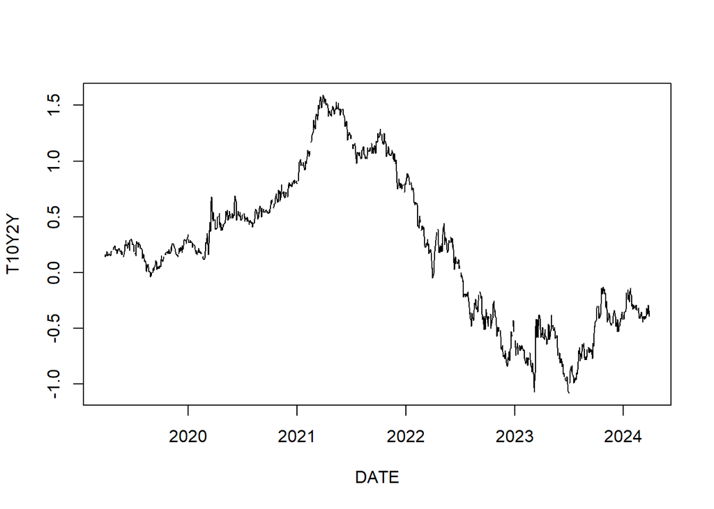

```r
yieldcurve<- read.csv("C:/Users/natha/Desktop/T10Y2Y.csv") %>%
  mutate(DATE = as.Date(DATE, format = "%Y-%m-%d"),
         T10Y2Y = as.numeric(T10Y2Y))
plot(yieldcurve,type="l")
```

Importation de l’inflation rate :

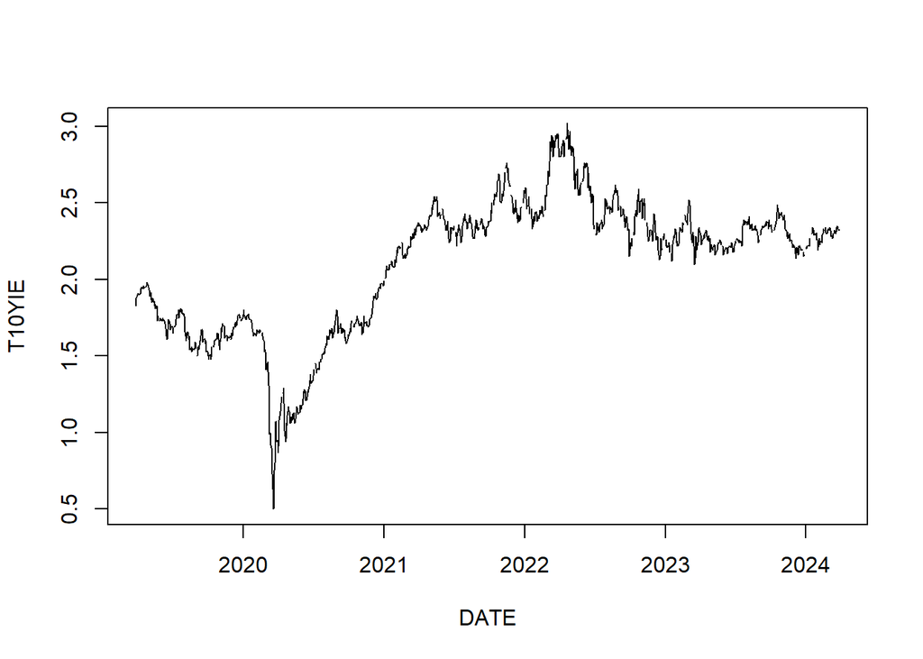

```r
inflation<- read.csv("C:/Users/natha/Desktop/T10YIE.csv") %>%
  mutate(DATE = as.Date(DATE, format = "%Y-%m-%d"),
         T10YIE = as.numeric(T10YIE))
plot(inflation,type="l")
```

Importation du VIX :

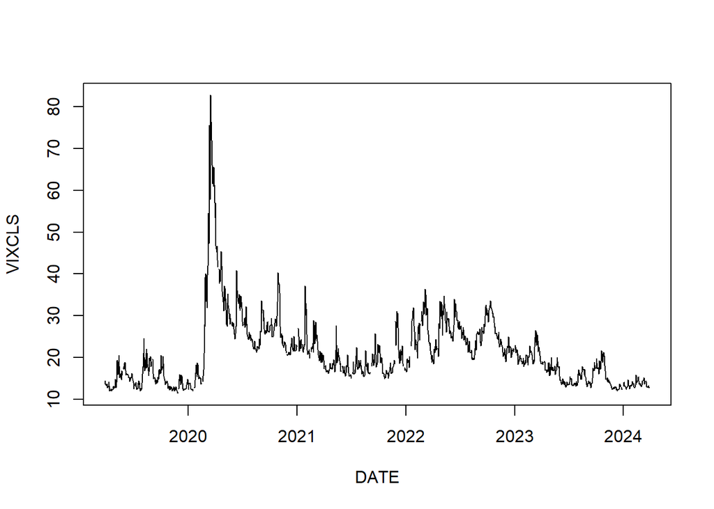

```r
vix<- read.csv("C:/Users/natha/Desktop/VIXCLS.csv") %>%
  mutate(DATE = as.Date(DATE, format = "%Y-%m-%d"),
         VIXCLS = as.numeric(VIXCLS))
plot(vix,type="l")
```

Concernant la courbe de la pente de la courbe des rdt correspond à l’anticipation que le marché fait sur la croissance aux US. Lorsque celui-ci monte, cela signifie que les gens s’attendent à une bonne croissance économique au US dans les prochaines années. Et à l’inverse si cela descends cela signifie donc une chute de l’économie au US. Concernant la courbe de l’inflation, cela correspond de la même manière à une attente d’une augmentation de l’inflation si celle-ci monte et à l’inverse une baisse de cette dernière. Pour finir le VIX mesure la volatilite, donc le risque/incertitude que l’on pourrait avoir sur les marchés. Une période avec un VIX élévé, peut révélé donc de nombreux changements dans les prix des actifs sur le S&P500. En période de ralentissement économique : on s’attends à avoir un inversement de la pente des rendemments, une baisse de l’inflation et un VIX élevé car beaucoup d’incertitudes. En période d’accélération économique : on s’attends à avoir une pente des rendemments élevés, une augmentation de l’inflation et un VIX plus faible.

### Question 2 : Regardons la stationnarité requise pour le test ADF et transformons les times series

```r
curves<- data.frame(yieldcurve, inflation, vix)
clean <- na.omit(curves)
yieldcurvec <- clean$T10Y2Y
inflationc <- clean$T10YIE
vixc <- clean$VIXCLS
tsyieldcurve <- ts((yieldcurvec), frequency = 12)
tsinflation <- ts((inflationc), frequency = 12)
tsvix <- ts((vixc), frequency = 12)
```

ADF test sur le yield curve

```r
trendyieldcurve <- ur.df(tsyieldcurve, type="trend", selectlags=c("BIC"))
summary(trendyieldcurve)
```

```
##
## ###############################################
## # Augmented Dickey-Fuller Test Unit Root Test #
## ###############################################
##
## Test regression trend
##
##
## Call:
## lm(formula = z.diff ~ z.lag.1 + 1 + tt + z.diff.lag)
##
## Residuals:
##      Min       1Q   Median       3Q      Max
## -0.15885 -0.02414 -0.00119  0.02317  0.42143
##
## Coefficients:
##               Estimate Std. Error t value Pr(>|t|)
## (Intercept)  4.235e-03  3.068e-03   1.380    0.168
## z.lag.1     -3.569e-03  2.208e-03  -1.617    0.106
## tt          -6.235e-06  4.036e-06  -1.545    0.123
## z.diff.lag  -3.884e-02  2.831e-02  -1.372    0.170
##
## Residual standard error: 0.0433 on 1245 degrees of freedom
## Multiple R-squared:  0.004188,   Adjusted R-squared:  0.001788
## F-statistic: 1.745 on 3 and 1245 DF,  p-value: 0.1559
##
##
## Value of test-statistic is: -1.6169 1.1275 1.6267
##
## Critical values for test statistics:
##       1pct  5pct 10pct
## tau3 -3.96 -3.41 -3.12
## phi2  6.09  4.68  4.03
## phi3  8.27  6.25  5.34
```

```r
driftyieldcurve <- ur.df(tsyieldcurve, type="drift", selectlags=c("BIC"))
summary(driftyieldcurve)
```

```
##
## ###############################################
## # Augmented Dickey-Fuller Test Unit Root Test #
## ###############################################
##
## Test regression drift
##
##
## Call:
## lm(formula = z.diff ~ z.lag.1 + 1 + z.diff.lag)
##
## Residuals:
##      Min       1Q   Median       3Q      Max
## -0.16010 -0.02444  0.00039  0.02229  0.42123
##
## Coefficients:
##               Estimate Std. Error t value Pr(>|t|)
## (Intercept) -6.591e-05  1.290e-03  -0.051    0.959
## z.lag.1     -1.731e-03  1.860e-03  -0.930    0.352
## z.diff.lag  -3.886e-02  2.833e-02  -1.372    0.170
##
## Residual standard error: 0.04333 on 1246 degrees of freedom
## Multiple R-squared:  0.002278,   Adjusted R-squared:  0.000677
## F-statistic: 1.423 on 2 and 1246 DF,  p-value: 0.2414
##
##
## Value of test-statistic is: -0.9303 0.4972
##
## Critical values for test statistics:
##       1pct  5pct 10pct
## tau2 -3.43 -2.86 -2.57
## phi1  6.43  4.59  3.78
```

Même constatation que précédemment, on a -2.86< -0.93 au seuil de 5% donc non stationnaire. Pour enlever ces composants, on propose de différencier une fois et répéter un test ADF :

```r
diffyieldcurve = na.omit(diff(tsyieldcurve, differences = 1))
difftrendyieldcurve <- ur.df(diffyieldcurve , type = "trend", selectlags = c("BIC"))
summary(difftrendyieldcurve)
```

```
##
## ###############################################
## # Augmented Dickey-Fuller Test Unit Root Test #
## ###############################################
##
## Test regression trend
##
##
## Call:
## lm(formula = z.diff ~ z.lag.1 + 1 + tt + z.diff.lag)
##
## Residuals:
##      Min       1Q   Median       3Q      Max
## -0.15994 -0.02379 -0.00059  0.02329  0.41871
##
## Coefficients:
##               Estimate Std. Error t value Pr(>|t|)
## (Intercept)  1.142e-03  2.456e-03   0.465   0.6420
## z.lag.1     -9.850e-01  4.086e-02 -24.105   <2e-16 ***
## tt          -2.521e-06  3.404e-06  -0.741   0.4590
## z.diff.lag  -5.294e-02  2.832e-02  -1.869   0.0619 .
## ---
## Signif. codes:  0 '***' 0.001 '**' 0.01 '*' 0.05 '.' 0.1 ' ' 1
##
## Residual standard error: 0.0433 on 1244 degrees of freedom
## Multiple R-squared:  0.5212, Adjusted R-squared:   0.52
## F-statistic: 451.4 on 3 and 1244 DF,  p-value: < 2.2e-16
##
##
## Value of test-statistic is: -24.1054 193.6916 290.5364
##
## Critical values for test statistics:
##       1pct  5pct 10pct
## tau3 -3.96 -3.41 -3.12
## phi2  6.09  4.68  4.03
## phi3  8.27  6.25  5.34
```

Maintenant, nous sommes bon, la courbe yield curve différenciée une fois est stationnaire car -3.41>-24.10 donc nous avons réussi à la rendre stationnaire et rejette H0.

ADF test sur le inflation

```r
trendinflation <- ur.df(tsinflation, type="trend", selectlags=c("BIC"))
summary(trendinflation)
```

[output not shown]

```r
driftinflation <- ur.df(tsinflation, type="drift", selectlags=c("BIC"))
summary(driftinflation)
```

[output not shown]

```r
diffinflation = na.omit(diff(tsinflation, differences = 1))
difftrendinflation <- ur.df(diffinflation , type = "trend", selectlags = c("BIC"))
summary(difftrendinflation)
```

```
##
## ###############################################
## # Augmented Dickey-Fuller Test Unit Root Test #
## ###############################################
##
## Test regression trend
##
##
## Call:
## lm(formula = z.diff ~ z.lag.1 + 1 + tt + z.diff.lag)
##
## Residuals:
##       Min        1Q    Median        3Q       Max
## -0.313975 -0.020046  0.000881  0.020903  0.261465
##
## Coefficients:
##               Estimate Std. Error t value Pr(>|t|)
## (Intercept)  2.702e-04  2.122e-03   0.127    0.899
## z.lag.1     -9.400e-01  3.825e-02 -24.573   <2e-16 ***
## tt           7.413e-08  2.939e-06   0.025    0.980
## z.diff.lag   3.041e-02  2.832e-02   1.074    0.283
## ---
## Signif. codes:  0 '***' 0.001 '**' 0.01 '*' 0.05 '.' 0.1 ' ' 1
##
## Residual standard error: 0.03741 on 1244 degrees of freedom
## Multiple R-squared:  0.4567, Adjusted R-squared:  0.4554
## F-statistic: 348.6 on 3 and 1244 DF,  p-value: < 2.2e-16
##
##
## Value of test-statistic is: -24.5731 201.2808 301.9207
##
## Critical values for test statistics:
##       1pct  5pct 10pct
## tau3 -3.96 -3.41 -3.12
## phi2  6.09  4.68  4.03
## phi3  8.27  6.25  5.34
```

Maintenant, nous sommes bon, la courbe inflation différenciée une fois est stationnaire car -3.41>-24.57 donc nous avons réussi à la rendre stationnaire et rejette H0.

ADF test sur le VIX

```r
trendvix <- ur.df(tsvix, type="trend", selectlags=c("BIC"))
summary(trendvix)
```

```
##
## ###############################################
## # Augmented Dickey-Fuller Test Unit Root Test #
## ###############################################
##
## Test regression trend
##
##
## Call:
## lm(formula = z.diff ~ z.lag.1 + 1 + tt + z.diff.lag)
##
## Residuals:
##      Min       1Q   Median       3Q      Max
## -11.2922  -0.9092  -0.2234   0.5671  23.8927
##
## Coefficients:
##               Estimate Std. Error t value Pr(>|t|)
## (Intercept)  0.6739636  0.2063137   3.267 0.001118 **
## z.lag.1     -0.0265824  0.0071848  -3.700 0.000225 ***
## tt          -0.0001761  0.0001647  -1.070 0.284957
## z.diff.lag  -0.2305682  0.0275662  -8.364  < 2e-16 ***
## ---
## Signif. codes:  0 '***' 0.001 '**' 0.01 '*' 0.05 '.' 0.1 ' ' 1
##
## Residual standard error: 2.069 on 1245 degrees of freedom
## Multiple R-squared:  0.06974,    Adjusted R-squared:  0.0675
## F-statistic: 31.11 on 3 and 1245 DF,  p-value: < 2.2e-16
##
##
## Value of test-statistic is: -3.6998 4.6339 6.9507
##
## Critical values for test statistics:
##       1pct  5pct 10pct
## tau3 -3.96 -3.41 -3.12
## phi2  6.09  4.68  4.03
## phi3  8.27  6.25  5.34
```

A 5%, on remarque que notre valeur de la valeur critique est de -3.41 > -3.69 donc on rejette H0 au seuil de 5% et on affirme que le VIX est déjà stationnaire.

```r
tsvix <- tsvix[-1]#supprime la première valeur pr avoir le même nombre de valeur car les deux autres séries étant différenciée une fois.
```

### Question 3 : Expliquer les critères d’informations et déterminer le nombre optimal de retard pour votre modèle.

Il existe plusieurs critères d’informations qui servent à donner le nombre de retard optimal pour avoir le moins d’erreurs possibles et une calibration intéressante. BIC, correspond à un critère qui sous-estime souvent le nombre de retard donc plus simples AIC, correspond à un critère souvent qui sur-estime le nombre de retard. Schwartz critère qui introduit une contrainte supplémentaire par rapport au AIC et qui réduit ainsi le nombre de retard optimaux.

Nous allons calculer nos critères jusqu’à 5 retards :

```r
bic <- numeric(5)
aic <- numeric(5)
diff <- data.frame(diffyieldcurve, diffinflation, tsvix)
for (lag in 1:5){
  var <- VAR(diff, p=lag, type="const")
  bic[lag] <- BIC(var)
  aic[lag] <- AIC(var)
}
print(aic)
```

```
## [1] -3677.847 -3765.794 -3771.168 -3787.916 -3783.426
```

```r
print(bic)
```

```
## [1] -3616.286 -3658.078 -3617.313 -3587.936 -3537.335
```

```r
#Je sélectionne maintenant le niveau de aic et bic le plus petit pour définir le nombre de retards à prendre.
lagBIC <- which.min(bic)
lagAIC <- which.min(aic)
lagBIC
```

```
## [1] 2
```

```r
lagAIC
```

```
## [1] 4
```

```r
plag = lagBIC
```

Ainsi nous avons un lag optimal égal à 2 pour le BIC contre un lag optimal de 4 pour le AIC. Nous allons choisir le plus petit afin de simplifier notre modèle et le temps de calcul d’où celui retenu de 2.

### Question 4 & 5 :Estimer le modèle et vérifier la stationnarité de notre modèle en affichant les racines du modèle.

```r
modelVAR = VAR(diff, p = plag, type = "const")
modelVAR
```

```
##
## VAR Estimation Results:
## =======================
##
## Estimated coefficients for equation diffyieldcurve:
## ===================================================
## Call:
## diffyieldcurve = diffyieldcurve.l1 + diffinflation.l1 + tsvix.l1 + diffyieldcurve.l2 + diffinflation.l2 + tsvix.l2 + const
##
## diffyieldcurve.l1  diffinflation.l1          tsvix.l1 diffyieldcurve.l2
##      -0.034435647      -0.013216740       0.001964613       0.063029909
##  diffinflation.l2          tsvix.l2             const
##      -0.058292962      -0.001868123      -0.002450630
##
##
## Estimated coefficients for equation diffinflation:
## ==================================================
## Call:
## diffinflation = diffyieldcurve.l1 + diffinflation.l1 + tsvix.l1 + diffyieldcurve.l2 + diffinflation.l2 + tsvix.l2 + const
##
## diffyieldcurve.l1  diffinflation.l1          tsvix.l1 diffyieldcurve.l2
##      0.0186278461      0.0667083659     -0.0012257830     -0.0073964213
##  diffinflation.l2          tsvix.l2             const
##     -0.0193659225      0.0012720159     -0.0006581935
##
##
## Estimated coefficients for equation tsvix:
## ==========================================
## Call:
## tsvix = diffyieldcurve.l1 + diffinflation.l1 + tsvix.l1 + diffyieldcurve.l2 + diffinflation.l2 + tsvix.l2 + const
##
## diffyieldcurve.l1  diffinflation.l1          tsvix.l1 diffyieldcurve.l2
##        -0.6567253         0.9414821         0.7496604         0.5365247
##  diffinflation.l2          tsvix.l2             const
##        -1.4442475         0.2247527         0.5432860
```

```r
roots <- roots(modelVAR)
roots
```

```
## [1] 0.9791507 0.2574091 0.2574091 0.2456460 0.1448973 0.1448973
```

On remarque les racines obtenues sont toutes inférieures à 1 en module, ainsi le modèle VAR est stationnaire.

### Question 6 : Réaliser tous les tests de causalité de Granger et confirmez votre intuitons.

```r
#Qui cause l'inflation ?
grangertest(diffinflation ~ diffyieldcurve, order = 2, data = diff)
```

```
## Granger causality test
##
## Model 1: diffinflation ~ Lags(diffinflation, 1:2) + Lags(diffyieldcurve, 1:2)
## Model 2: diffinflation ~ Lags(diffinflation, 1:2)
##   Res.Df Df      F Pr(>F)
## 1   1243
## 2   1245 -2 0.2905  0.748
```

```r
grangertest(diffinflation ~ tsvix, order = 2, data = diff)
```

```
## Granger causality test
##
## Model 1: diffinflation ~ Lags(diffinflation, 1:2) + Lags(tsvix, 1:2)
## Model 2: diffinflation ~ Lags(diffinflation, 1:2)
##   Res.Df Df      F  Pr(>F)
## 1   1243
## 2   1245 -2 2.9558 0.05241 .
## ---
## Signif. codes:  0 '***' 0.001 '**' 0.01 '*' 0.05 '.' 0.1 ' ' 1
```

```r
#Qui cause la yield curve ?
grangertest(diffyieldcurve ~ diffinflation, order = 2, data = diff)
```

```
## Granger causality test
##
## Model 1: diffyieldcurve ~ Lags(diffyieldcurve, 1:2) + Lags(diffinflation, 1:2)
## Model 2: diffyieldcurve ~ Lags(diffyieldcurve, 1:2)
##   Res.Df Df      F Pr(>F)
## 1   1243
## 2   1245 -2 2.1487 0.1171
```

```r
grangertest(diffyieldcurve ~ tsvix, order = 2, data = diff)
```

```
## Granger causality test
##
## Model 1: diffyieldcurve ~ Lags(diffyieldcurve, 1:2) + Lags(tsvix, 1:2)
## Model 2: diffyieldcurve ~ Lags(diffyieldcurve, 1:2)
##   Res.Df Df      F   Pr(>F)
## 1   1243
## 2   1245 -2 5.8471 0.002968 **
## ---
## Signif. codes:  0 '***' 0.001 '**' 0.01 '*' 0.05 '.' 0.1 ' ' 1
```

```r
#Qui cause le VIX?
grangertest(tsvix ~ diffinflation, order = 2, data = diff)
```

```
## Granger causality test
##
## Model 1: tsvix ~ Lags(tsvix, 1:2) + Lags(diffinflation, 1:2)
## Model 2: tsvix ~ Lags(tsvix, 1:2)
##   Res.Df Df      F Pr(>F)
## 1   1243
## 2   1245 -2 0.4106 0.6633
```

```r
grangertest(tsvix ~ diffyieldcurve, order = 2, data = diff)
```

```
## Granger causality test
##
## Model 1: tsvix ~ Lags(tsvix, 1:2) + Lags(diffyieldcurve, 1:2)
## Model 2: tsvix ~ Lags(tsvix, 1:2)
##   Res.Df Df      F Pr(>F)
## 1   1243
## 2   1245 -2 0.0963 0.9082
```

### Question 7 : Faire tourner les tests de qualité.

```r
#Test SERIAL CORRELATION
serial <- serial.test(modelVAR)
serial
```

```
##
##  Portmanteau Test (asymptotic)
##
## data:  Residuals of VAR object modelVAR
## Chi-squared = 212.13, df = 126, p-value = 2.471e-06
```

```r
#Test ARCH
arch <- arch.test(modelVAR)
arch
```

```
##
##  ARCH (multivariate)
##
## data:  Residuals of VAR object modelVAR
## Chi-squared = 2100.6, df = 180, p-value < 2.2e-16
```

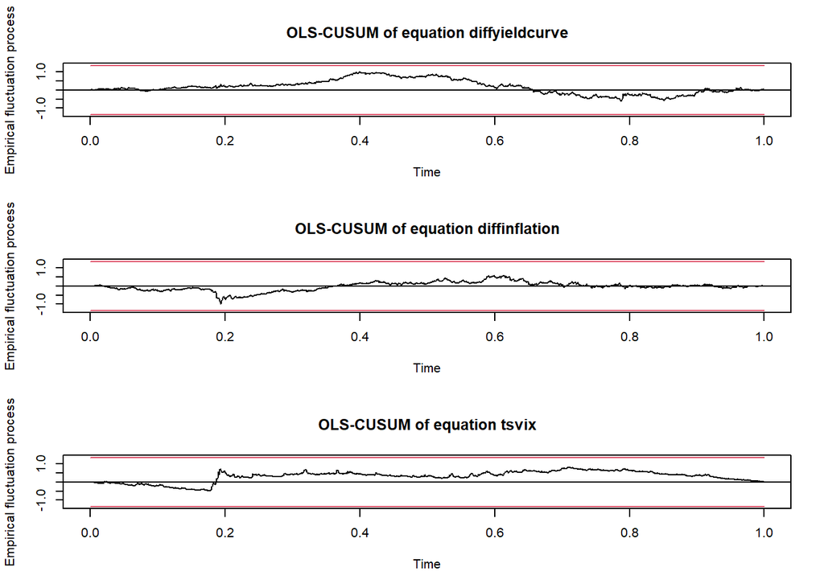

```r
#Test stabilité
stability <- stability(modelVAR)
plot(stability)
```

On remarque que pour le test de portmanteau la p value est bien inférieur à 0.05 donc on rejette H0 et donc on peut dire qu’il existe une corrélation entre les résidus. Donc le modèle n’arrive pas à capturer les interpendances entre les données , les résidus devrait être sans corrélation. Le test ARCH permet d’affirmer que la p value < 0.05 et donc il y a de l’hétéroscédasticité entre les résidus, ce qui confirme que le modèle n’arrive pas à être valable. Il y a une certaine instabilités dans les coefficients car ils varient beaucoup selon le graphe de stabilités. Mais cela reste tout de même correct vis à vis de l’intervalle de confiance.

### Question 8 : Calculer et afficher tout les IRF et expliquer les résultats obtenus.

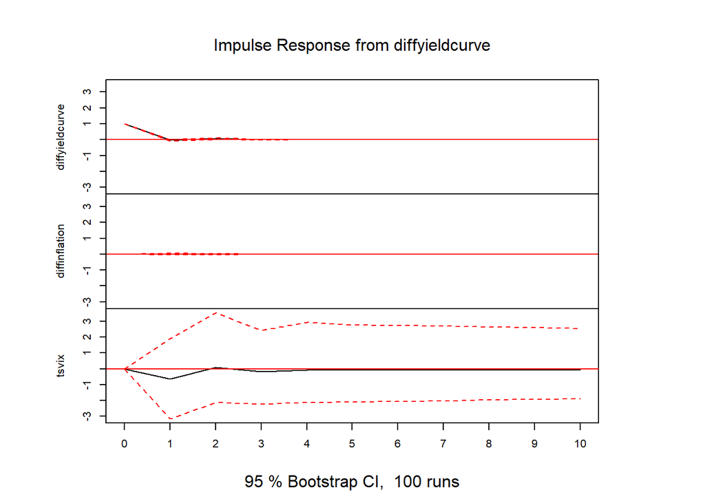

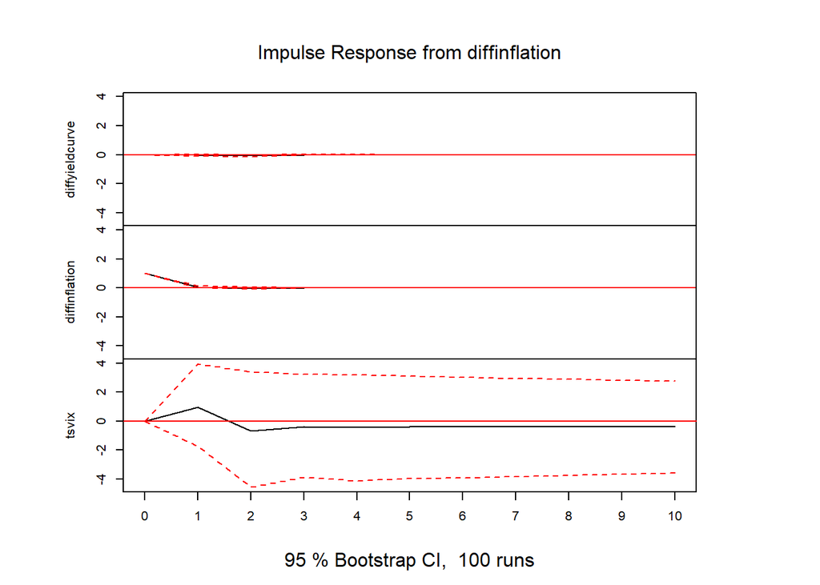

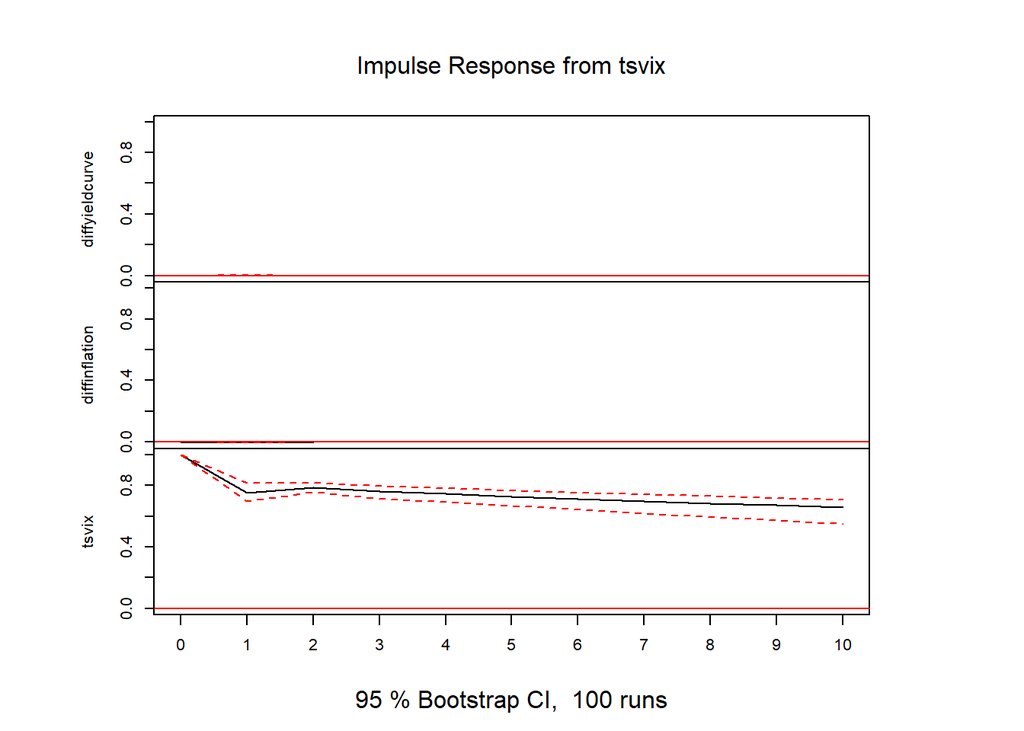

```r
irffinal <- irf(modelVAR, impulse = c("diffyieldcurve", "diffinflation", "tsvix"), response = c("diffyieldcurve", "diffinflation", "tsvix"), n.ahead = 10, ortho = FALSE)
plot(irffinal)
```

### Question 9 : Prédire 3 mois en utilisant les graphiques. Est ce que cela confirme notre théorie, regarder la FEDV et commenter.

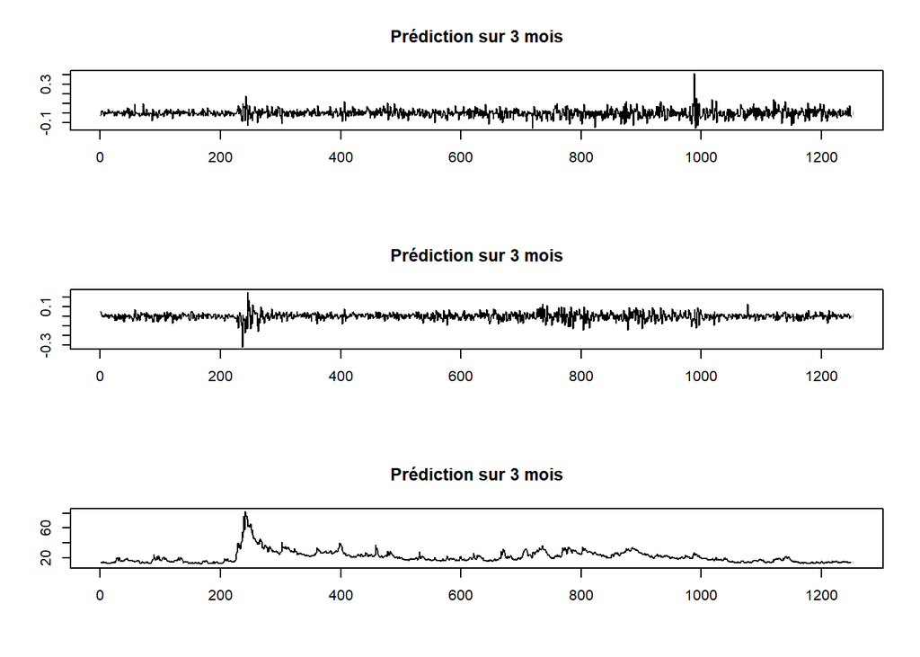

```r
forecast <- predict(modelVAR, n.ahead = 3)
chart <- fanchart(forecast, main = "Prédiction sur 3 mois")
```

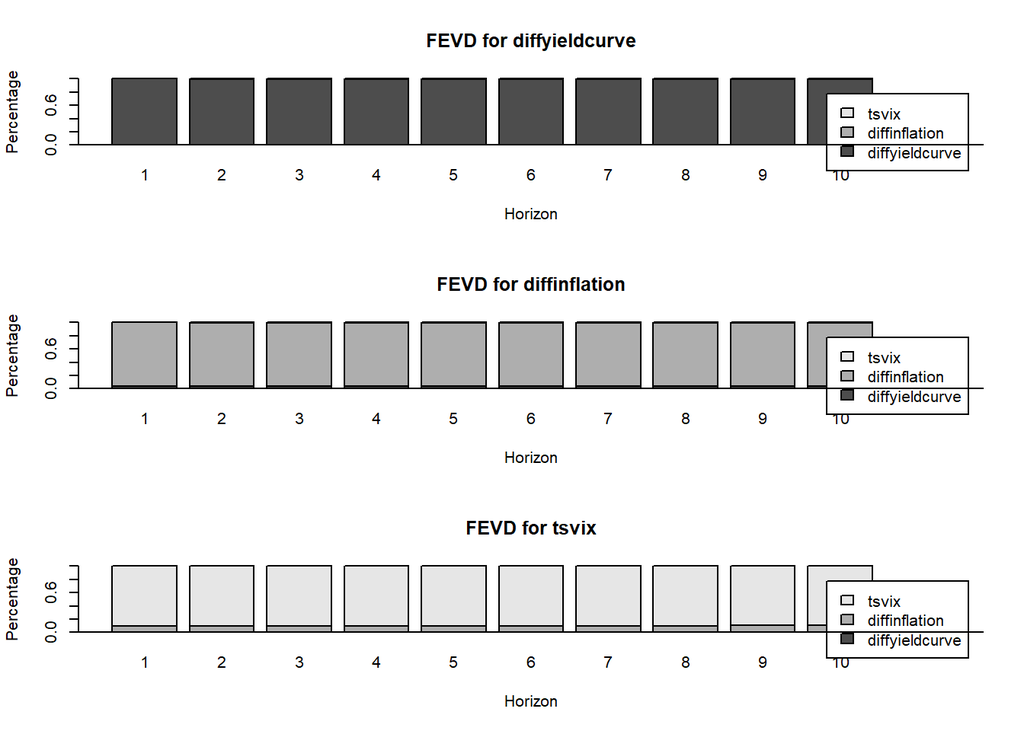

```r
plot(fevd(modelVAR, n.ahead = 10))
```

La prédiction à 3 mois du VIX, on a que lorsque le VIX augmente rapidement (comme pour le pic à 200), on a en résultat une grosse variation sur l’inflation autour des 200. Ce qui signifie que ces 2 données sont très complémentaires. Au niveau de la prédiction des erreurs on a que l’erreur du la yield curve et inflation provient d’eux même. Cependant pour le vix, environ 10% provient du de l’inflation, ce qui confirme nos précédentes hypothèses.

### Question 10 :Trouver une façon pour imposer de mettre 0 à certains coefficients. Ensuite tourner les estimations de IRF et commenter

```r
varconstraint = VAR(diff, p = 2)
coefsconstraint <- coef(modelVAR)
print(coefsconstraint)
```

```
## $diffyieldcurve
##                       Estimate   Std. Error    t value    Pr(>|t|)
## diffyieldcurve.l1 -0.034435647 0.0287506460 -1.1977347 0.231249012
## diffinflation.l1  -0.013216740 0.0346860739 -0.3810388 0.703239672
## tsvix.l1           0.001964613 0.0006007255  3.2704012 0.001103444
## diffyieldcurve.l2  0.063029909 0.0286961687  2.1964573 0.028243662
## diffinflation.l2  -0.058292962 0.0335002836 -1.7400737 0.082093971
## tsvix.l2          -0.001868123 0.0006001127 -3.1129542 0.001894589
## const             -0.002450630 0.0033792703 -0.7251951 0.468469095
##
## $diffinflation
##                        Estimate   Std. Error    t value   Pr(>|t|)
## diffyieldcurve.l1  0.0186278461 0.0249138173  0.7476914 0.45478799
## diffinflation.l1   0.0667083659 0.0300571509  2.2193842 0.02664085
## tsvix.l1          -0.0012257830 0.0005205575 -2.3547503 0.01869021
## diffyieldcurve.l2 -0.0073964213 0.0248666101 -0.2974439 0.76617742
## diffinflation.l2  -0.0193659225 0.0290296067 -0.6671094 0.50482629
## tsvix.l2           0.0012720159 0.0005200265  2.4460596 0.01458079
## const             -0.0006581935 0.0029283002 -0.2247698 0.82219534
##
## $tsvix
##                     Estimate Std. Error    t value      Pr(>|t|)
## diffyieldcurve.l1 -0.6567253 1.38210933 -0.4751616  6.347554e-01
## diffinflation.l1   0.9414821 1.66743893  0.5646277  5.724291e-01
## tsvix.l1           0.7496604 0.02887825 25.9593450 4.972626e-119
## diffyieldcurve.l2  0.5365247 1.37949049  0.3889296  6.973950e-01
## diffinflation.l2  -1.4442475 1.61043528 -0.8968057  3.699966e-01
## tsvix.l2           0.2247527 0.02884879  7.7907132  1.400030e-14
## const              0.5432860 0.16244926  3.3443427  8.494050e-04
```

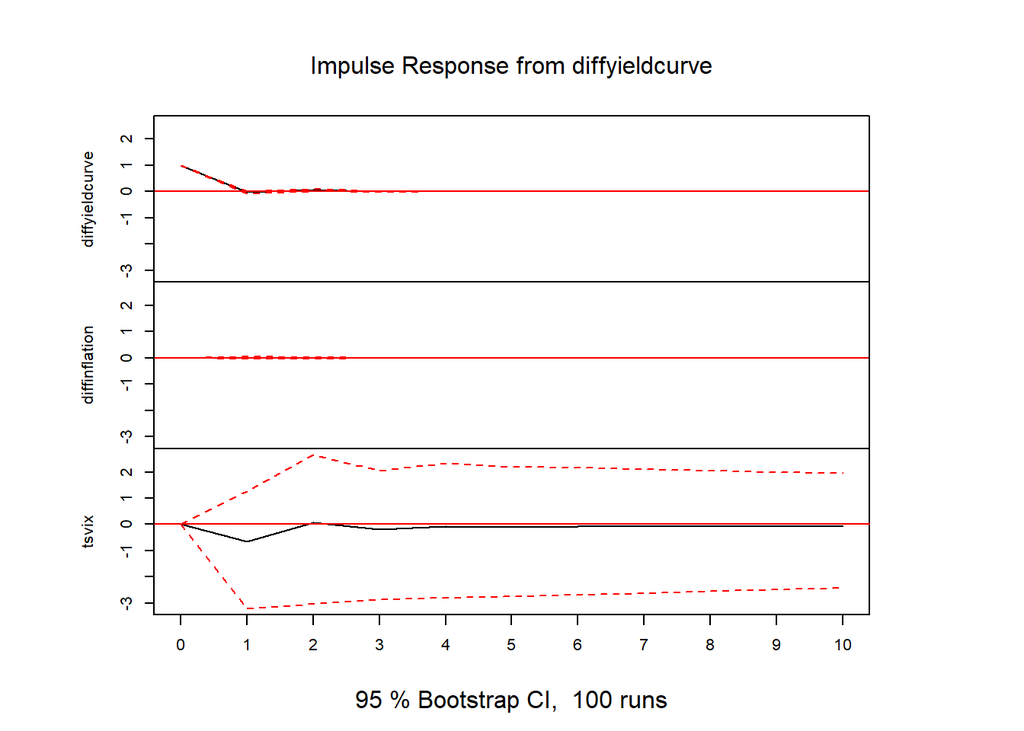

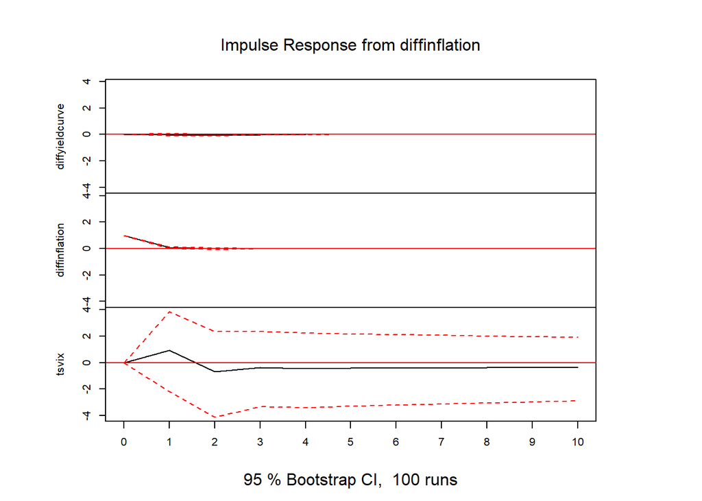

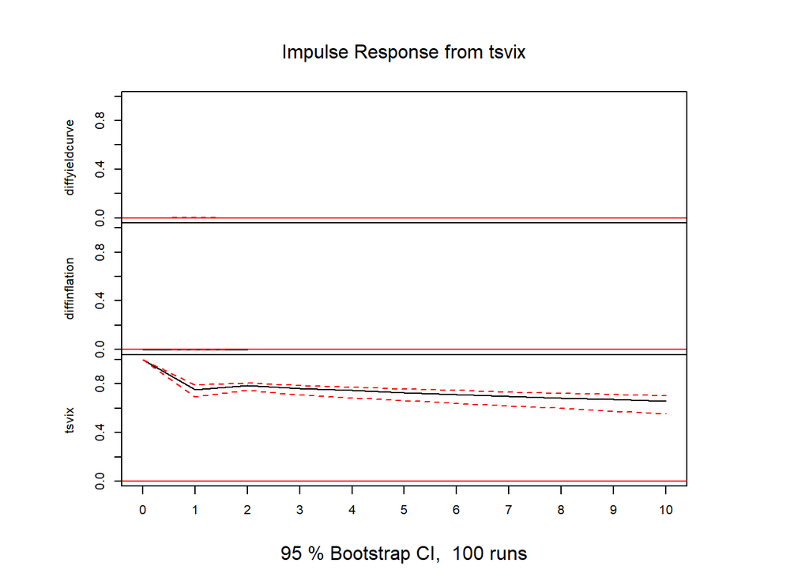

```r
coefsconstraint$diffyieldcurve$tsvix<- 0
irfconstraint <- irf(varconstraint, impulse = c("diffyieldcurve", "diffinflation", "tsvix"), response = c("diffyieldcurve", "diffinflation", "tsvix"), n.ahead = 10, ortho = FALSE)
plot(irfconstraint)
```